# assignment07

Jeff Nguyen

17/10/2020

**University of Southern California**  
**Marshall School of Business**  
**FBE 506 Quantitative Method in Finance**

Assignment 07  
Student Name: Ngoc Son (Jeff) Nguyen  
Student ID: 6524885309

# **Question 1**

```r
a11 <- 15
a12 <- 1
a21 <- 1
a22 <- 2

x1 <- .2
x2 <- .5

detA <- a11*a22 - a12*a21
```

$$\begin{equation}
\begin{aligned}
A & = \begin{pmatrix} 15 & 1 \\ 1 & 2 \\ \end{pmatrix} \\
X & = \begin{pmatrix} 0.2 \\ 0.5 \\ \end{pmatrix}
\end{aligned}
\end{equation}$$

## a. Find determinant of A

$$\begin{equation}
\begin{aligned}
detA & = \begin{vmatrix} 15 & 1 \\ 1 & 2 \\ \end{vmatrix} \\
& = 15 * 2 - 1 * 1 \\
& = 29\\
\end{aligned}
\end{equation}$$

## b. Find the inverse of A

$$\begin{equation}
\begin{aligned}
A^{-1} & = \frac{1}{detA} * \begin{pmatrix} 2 & -1 \\ -1 & 15 \\ \end{pmatrix} \\
& = \frac{1}{29} * \begin{pmatrix} 2 & -1 \\ -1 & 15 \\ \end{pmatrix} \\
& = \begin{pmatrix} \frac{2}{29} & \frac{-1}{29} \\ \frac{-1}{29} & \frac{15}{29} \\ \end{pmatrix} \\
\end{aligned}
\end{equation}$$

## c. Find the trace of A

$$\begin{equation}
\begin{aligned}
tr(A) & = 15 + 2 \\
& = 17\\
\end{aligned}
\end{equation}$$

## d. Find the quadractic form X’AX

$$\begin{equation}
\begin{aligned}
x'Ax & = a_{11} * x_1^2 + (a_{12} + a_{21}) *x_1*x_2 + a_{22} * x_2^2 \\
& = 1.3 \\
\end{aligned}
\end{equation}$$

## e. Find $x_1:x_2$ that min(X’AX)

Let $k = \frac{x_1}{x_2}$. We have $x_1 = k * x_2$. Substitute in $x'Ax$:

$$\begin{equation}
\begin{aligned}
x'Ax & = a_{11} * x_1^2 + (a_{12} + a_{21}) *x_1*x_2 + a_{22} * x_2^2 \\
& = a_{11} * k^2 * x_2^2 + (a_{12} + a_{21}) *k*x_2^2 + a_{22} * x_2^2 \\
& = 15 * k^2 * x_2^2 + 2 *k*x_2^2 + 2 * x_2^2 \\
& = (15*k^2 + 2*k + 2) * x_2^2 \\
\end{aligned}
\end{equation}$$

Find the critical point of x’Ax: $z = f(x_1, x_2) = 15*x_1^2+ 2*x_1*x_2 + 2*x_2^2$ The first order condition is:

$$\begin{equation}
\begin{aligned}
\frac{\partial f}{\partial x_1} &= 0 \\
30 * x_1 + 2*x_2 &= 0 \\
\end{aligned}
\end{equation}$$

$$\begin{equation}
\begin{aligned}
\frac{\partial f}{\partial x_2} &= 0 \\
4 * x_2 + 2*x_1 &= 0 \\
\end{aligned}
\end{equation}$$

Solving the two above equation together yields $x_1 = 0$, $x_2 = 0$ and $z = 0$. Thus the point $(0,0,0)$ is the extrema.

To test for the second order condition, form the Hessian:

$$\begin{equation}
\begin{aligned}
H & = \begin{pmatrix} f_{xx} & f_{xy} \\ f_{yx} & f_{yy} \\ \end{pmatrix} \\
H & = \begin{pmatrix} f_{x_1x_1} & f_{x_1x_2} \\ f_{x_2x_1} & f_{x_2x_2} \\ \end{pmatrix} \\
H & = \begin{pmatrix} 30 & 2 \\ 2 & 4 \\ \end{pmatrix} \\
\end{aligned}
\end{equation}$$

We can see:

$$\begin{equation}
\begin{aligned}
\begin{vmatrix} 30 \\ \end{vmatrix} \\ > 0 \\
\begin{vmatrix} 30 & 2 \\ 2 & 4 \\ \end{vmatrix} \\ = 30*4 - 2*2 > 0
\end{aligned}
\end{equation}$$

Thus H is positive definite and have a minimum at (0,0,0).

## f. Find $x_1:x_2$ that min(X’AX) s.t. $x_1 + x_2 = 1$

Similar to e. but adding the constraint $g(x1, x2) = x_1 + x_2 = 1$

The Lagrange becomes:

$$\begin{equation}
\begin{aligned}
L(x_1,x_2,\lambda) & = 15*x_1^2 + 2*x_1*x_2 + 2*x_2^2 + \lambda*(1 - x_1 - x_2)
\end{aligned}
\end{equation}$$

Find the critical point of $L(x_1,x_2,\lambda)$ The first order condition is:

$$\begin{equation}
\begin{aligned}
\frac{\partial L}{\partial x_1} &= 0 \\
30*x_1 + 2*x_2 - \lambda &= 0 \\
\end{aligned}
\end{equation}$$

$$\begin{equation}
\begin{aligned}
\frac{\partial L}{\partial x_2} &= 0 \\
2*x_1 + 4*x_2 - \lambda &= 0 \\
\end{aligned}
\end{equation}$$

Also

$$\begin{equation}
\begin{aligned}
x_1 + x_2 &= 0 \\
\end{aligned}
\end{equation}$$

The bordered Hessian matrix is:

$$\begin{equation}
\begin{aligned}
H & = \begin{pmatrix}
f_{\lambda \lambda} & f_{\lambda x_1} & f_{\lambda x_2 } \\
f_{x_1 \lambda} & f_{x_1 x_1} & f_{x_1 x_2 } \\
f_{x_2 \lambda} & f_{x_2 x_1} & f_{x_2 x_2 }
\end{pmatrix} \\
H & = \begin{pmatrix}
0 & -1 & -1 \\
-1 & 30 & 2 \\
-1 & 2 & 4 \\
\end{pmatrix} \\
\end{aligned}
\end{equation}$$

## g. Find the eigenvalues of A.

We have the 2x2 system $x' = A*x$ where
$$\begin{equation}
\begin{aligned}
A & = \begin{pmatrix} 15 & 1 \\ 1 & 2 \\ \end{pmatrix} \\
\end{aligned}
\end{equation}$$

Solve the characteristic equation of this system for the eigenvalues:

$$\begin{equation}
\begin{aligned}
\lambda^2 - tr(A) * \lambda + detA &= 0 \\
\lambda^2 - 17*\lambda + 29 & = 0 \\
\lambda &= \frac{17 \pm \sqrt{173}}{2} \\
\end{aligned}
\end{equation}$$

## h. Find the eigenvectors of A.

For $\lambda_1 = \frac{17 + \sqrt{173}}{2}$:  
We need to solve:

$$\begin{equation}
\begin{aligned}
(A - \lambda_1*I)v & = 0 \\
\begin{pmatrix} 15 - \frac{17 + \sqrt{173}}{2} & 1 \\ 1 & 2 - \frac{17 + \sqrt{173}}{2} \\ \end{pmatrix} * \begin{pmatrix} a_1 \\ a_2 \end{pmatrix} & = \begin{pmatrix} 0 \\ 0 \end{pmatrix} \\
\begin{pmatrix} \frac{13 - \sqrt{173}}{2} & 1 \\ 1 & \frac{-13 - \sqrt{173}}{2} \\ \end{pmatrix} * \begin{pmatrix} a_1 \\ a_2 \end{pmatrix} & = \begin{pmatrix} 0 \\ 0 \end{pmatrix} \\
\end{aligned}
\end{equation}$$

By inspection, the notrivial solutions to this system and hence the eigenvectors for the eigenvalue $\lambda_1 = \frac{17 + \sqrt{173}}{2}$ are all nonzero scalar multiples of:

$$\begin{equation}
\begin{aligned}
v_1 & = \begin{pmatrix} \frac{13 + \sqrt{173}}{2} \\ 1 \\ \end{pmatrix}
\end{aligned}
\end{equation}$$

For $\lambda_2 = \frac{17 - \sqrt{173}}{2}$:  
We need to solve:

$$\begin{equation}
\begin{aligned}
(A - \lambda_1*I)v & = 0 \\
\begin{pmatrix} 15 - \frac{17 - \sqrt{173}}{2} & 1 \\ 1 & 2 - \frac{17 - \sqrt{173}}{2} \\ \end{pmatrix} * \begin{pmatrix} a_1 \\ a_2 \end{pmatrix} & = \begin{pmatrix} 0 \\ 0 \end{pmatrix} \\
\begin{pmatrix} \frac{13 + \sqrt{173}}{2} & 1 \\ 1 & \frac{-13 + \sqrt{173}}{2} \\ \end{pmatrix} * \begin{pmatrix} a_1 \\ a_2 \end{pmatrix} & = \begin{pmatrix} 0 \\ 0 \end{pmatrix} \\
\end{aligned}
\end{equation}$$

By inspection, the notrivial solutions to this system and hence the eigenvectors for the eigenvalue $\lambda_1 = \frac{17 + \sqrt{173}}{2}$ are all nonzero scalar multiples of:

$$\begin{equation}
\begin{aligned}
v_1 & = \begin{pmatrix} \frac{13 - \sqrt{173}}{2} \\ 1 \\ \end{pmatrix}
\end{aligned}
\end{equation}$$

# **Question 2**

$$\begin{equation}
\begin{aligned}
A & = \begin{pmatrix} 3 & 0 & 1 \end{pmatrix} \\
B & = \begin{pmatrix} -1 & 4 & 5 \end{pmatrix} \\
C & = \begin{pmatrix} 1 & 3 & -1 \\ 2 & 3 & 1 \\ -1 & 1 & 0 \end{pmatrix} \\
\end{aligned}
\end{equation}$$

## a. Find $A'$, $C'$

$$\begin{equation}
\begin{aligned}
A' & = \begin{pmatrix} 3 \\ 0 \\ 1 \end{pmatrix} \\
C & = \begin{pmatrix} 1 & 2 & -1 \\ 3 & 3 & 1 \\ -1 & 1 & 0 \end{pmatrix} \\
\end{aligned}
\end{equation}$$

## b. Find $C^{-1}$

The matrix of cofactors from C is:
$$\begin{equation}
\begin{aligned}
\begin{pmatrix} -1 & -1 & 5 \\ -1 & -1 & -4 \\ 6 & -3 & -3 \end{pmatrix} \\
\end{aligned}
\end{equation}$$

Thus, the adjoint of C is:

$$\begin{equation}
\begin{aligned}
adj(C) & = \begin{pmatrix} -1 & -1 & 6 \\ -1 & -1 & -3 \\ 5 & -4 & -3 \end{pmatrix} \\
\end{aligned}
\end{equation}$$

Assume C is invertible then:

$$\begin{equation}
\begin{aligned}
C^{-1} &= \frac{1}{detC} * adj(C)
& = \frac{1}{1*(0-1) -3*(0+1) + (-1)*(2+3)} * \begin{pmatrix} -1 & -1 & 6 \\ -1 & -1 & -3 \\ 5 & -4 & -3 \end{pmatrix} \\
& = \frac{-1}{9} * \begin{pmatrix} -1 & -1 & 6 \\ -1 & -1 & -3 \\ 5 & -4 & -3 \end{pmatrix} \\
& = \begin{pmatrix} \frac{1}{9} & \frac{1}{9} & \frac{-2}{3} \\
\frac{1}{9} & \frac{1}{9} & \frac{1}{3} \\
\frac{-5}{9} & \frac{4}{9} & \frac{1}{3} \\
\end{pmatrix} \\
\end{aligned}
\end{equation}$$

$$\begin{equation}
\begin{aligned}
AB' & = \begin{pmatrix} 3 & 0 & 1 \end{pmatrix} * \begin{pmatrix} -1 \\ 4 \\ 5 \end{pmatrix} \\
& = \begin{pmatrix} 3*(-1) + 0*(4) + 1 * 5 \end{pmatrix} \\
& = \begin{pmatrix} 2 \end{pmatrix} \\
\end{aligned}
\end{equation}$$

$$\begin{equation}
\begin{aligned}
A'B & = \begin{pmatrix} 3 \\ 0 \\ 1 \end{pmatrix} * \begin{pmatrix} -1 & 4 & 5 \end{pmatrix} \\
& = \begin{pmatrix} 3*-1 & 3*4 & 3*5 \\ 0*-1 & 0*4 & 0*5 \\ 1*-1 & 1*4 & 1*5 \end{pmatrix} \\
& = \begin{pmatrix} -3 & 12 & 15 \\ 0 & 0 & 0 \\ -1 & 4 & 5 \end{pmatrix} \\
\end{aligned}
\end{equation}$$

$$\begin{equation}
\begin{aligned}
CA' & = \begin{pmatrix} 1 & 3 & -1 \\ 2 & 3 & 1 \\ -1 & 1 & 0 \end{pmatrix} * \begin{pmatrix} 3 \\ 0 \\ 1 \end{pmatrix} \\
& = \begin{pmatrix} 1*3 + 3*0 + -1*1 \\ 2*3 + 3*0 + 1*1 \\ -1*3 + 1*0 + 0*1 \end{pmatrix} \\
& = \begin{pmatrix} 2 \\ 7 \\ -3 \end{pmatrix} \\
\end{aligned}
\end{equation}$$

## d. Find tr(C)

$$\begin{equation}
\begin{aligned}
tr(C) & = 1 + 3 + 0 \\
& = 4
\end{aligned}
\end{equation}$$

## e.Find a vector orthogonal to A

V is orthogonal to A if V.A = 0. Thus, find value for V that satisfy:

$$\begin{equation}
\begin{aligned}
i*3 + j*0 + k*1 & = 0
\end{aligned}
\end{equation}$$

From observation, we can see there is a V(1,1,-3) satisfy the condition.

## f. Find the eigenvalues of A.

The characteristic polynomial of C is:

$$\begin{equation}
\begin{aligned}
det(\lambda I - A) & = \begin{vmatrix} \lambda-1 & -3 & 1 \\ -2 & \lambda-3 & -1 \\ 1 & -1 & \lambda \end{vmatrix} \\
& = \lambda^3 - 4*\lambda^2 - 5*\lambda + 9
\end{aligned}
\end{equation}$$

The eigenvalues therefore must satisfy the cubic equation:

$$\begin{equation}
\begin{aligned}
\lambda^3 - 4*\lambda^2 - 5*\lambda + 9 & = 0
\lambda = 1.099115, -1.757702, 4.658587
\end{aligned}
\end{equation}$$

Verify:

```r
C <- matrix(c(1,3,-1,2,3,1,-1,1,0),3,3, byrow=TRUE)
ev <- eigen(C)
ev$values
```

```
## [1]  4.658587 -1.757702  1.099115
```

## g. Find the eigenvectors of C.

```r
ev$vectors
```

```
##            [,1]       [,2]       [,3]
## [1,] 0.62852346  0.6713753 -0.6035847
## [2,] 0.77713615 -0.4117461  0.2341098
## [3,] 0.03190081  0.6162145  0.7621536
```

# **Question 3**

## a. Find the GMV solution, no short sale.

Given parameters

```r
# Mean Returns
mean_rStock1 <- .023
mean_rStock2 <- .021
mean_rf <- .008

# Variance of returns
var_rStock1 <- .0072
var_rStock2 <- .0049

# Standard deviation of returns
sd_rStock1 <- sqrt(var_rStock1)
sd_rStock2 <- sqrt(var_rStock2)

# Covariance of Returns
cov_rStock1_rStock2 <- .0023

# Correlation of Returns
cor_rStock2_rStock2 <- cov_rStock1_rStock2 / (sd_rStock1 * sd_rStock2)
```

| Asset | Mean Returns | Variance | Pair | $\sigma_{1,2}$ |
| --- | --- | --- | --- | --- |
| Stock 1 | 0.023 | 0.0072 | (1,2) | 0.0023 |
| Stock 2 | 0.021 | 0.0049 |  |  |
| Risk Free | 0.008 |  |  |  |

Since the investor’s objective is to minimize risk, we solve for the global minimum variance combination of the two assets. Let $x_i$ denotes the weight of the investment in asset i $(i = 1,2,3)$, and assume all money is invested in i, meaning $\sum {x_i} = x_1 + x_2 = 1$.

$$\begin{equation}
\begin{aligned}
\text {The returns of the portfolio is:} \\
R_{p,x} & = x_1 * r_1 + x_2 * r_2 \\
\text {The expected returns on the portfolio is:} \\
\mu_{p,x} & = E[R_{p,x}] \\
& = x_1 * \mu_1 + x_2 * \mu_2 \\
\text {The variance of the portfolio returns is:} \\
\sigma_{p,x}^2 & = var(R_{p,x}) \\
& = x_1^2 * \sigma_1^2 + x_2^2 * \sigma_2^2 + 2 * x_1 * x_2 * \sigma_{1,2}
\end{aligned}
\end{equation}$$

The global minimum variance portfolio $m = (m_1,m_2)$ is the solution of the constrained minimization problem:

$$\begin{equation}
\begin{aligned}
min \sigma_{p,m}^2 & = var(R_{p,m}) \\
& = m_1^2 * \sigma_1^2 + m_2^2 * \sigma_2^2 + 2 * m_1 * m_2 * \sigma_{1,2} \\
\text {s.t. } m_1 + m_2 & = 1 \\
\text {rewrite: } \\
min \sigma_{p,m}^2 & = min[m_1^2 * \sigma_1^2 + (1-m_1)^2 * \sigma_2^2 + 2 * m_1 * (1 - m_1) * \sigma_{1,2}] \\
& = min[m_1^2 * (\sigma_1^2 + \sigma_2^2 - 2 * \sigma_{1,2}) + m_1 * (2 * \sigma_{1,2} - 2 * \sigma_2^2) + \sigma_2^2] \\
\text {plug in: }
min \sigma_{p,m}^2 & = min[(0.0072 + 0.0049 - 2 * 0.0023) * m_1^2 + (2*0.0023 - 2*0.0049) * m_1 + 0.0049] \\
min \sigma_{p,m}^2 & = min[(0.0075) * m_1^2 + (-0.0052) * m_1 + 0.0049] \\
\end{aligned}
\end{equation}$$

Find the critical point:

$$\begin{equation}
\begin{aligned}
\frac{d\sigma_{p,m}^2}{dm} & = 0 \\
\frac{d(0.0075 * m_1^2 + (-0.0052) * m_1 + 0.0049)}{dm} & = 0 \\
.015* m_1 - .0052 & = 0 \\
m_1 & = .3467 = 34.67\% \\
\text {thus, } \\
m_2 & = 1 - 0.3467 = .6533 = 65.33\%
\end{aligned}
\end{equation}$$

**Recap:**

| Asset | Weight |
| --- | --- |
| Stock 1 | `34.67`% |
| Stock 2 | `65.33`% |

Graphing the function:

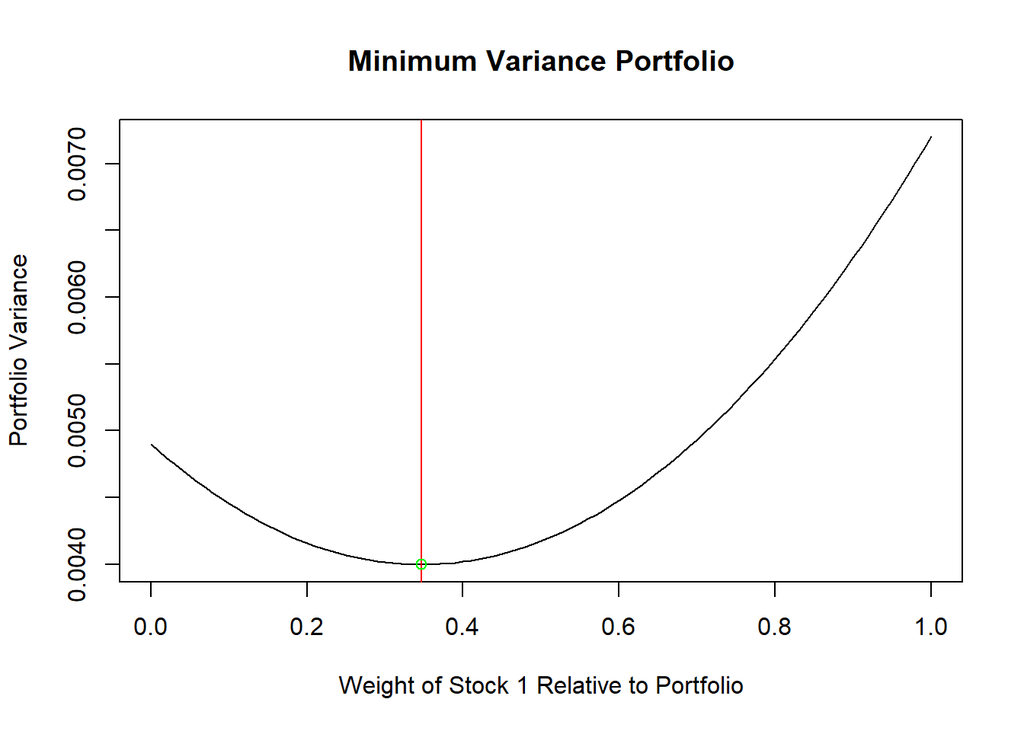

```r
# The Variance function of the portfolio
fVar <- function(m1) var_rStock1 * m1^2 + var_rStock2 * (1 - m1)^2 + 2 * m1 * (1 - m1) * cov_rStock1_rStock2

# Set the weighting
m1 <- .3467
m2 <- .6533

# Plot of the variance function with respect to w1.
w1 <- seq(0, 1, .05)
plot(fVar, w1, xlab = "Weight of Stock 1 Relative to Portfolio", ylab = "Portfolio Variance", main = "Minimum Variance Portfolio"); abline(v = m1, col = "red")
points(m1, fVar(m1), col='green')
```

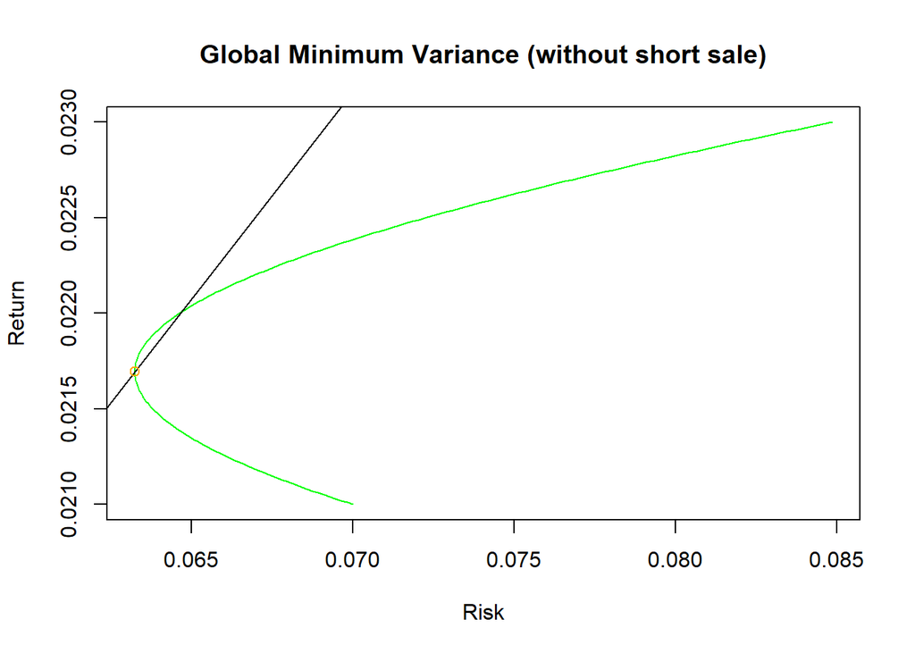

```r
# Plot of the efficient frontier, assume no short sale allowed
w1WithoutShort <- seq(0, 1, .005)
fVar <- function(w1) var_rStock1 * w1^2 + var_rStock2 * (1 - w1)^2 + 2 * w1 * (1 - w1) * cov_rStock1_rStock2
r <- function(w1) mean_rStock1*w1 + mean_rStock2*(1-w1)
riskWithoutShort <- sqrt(fVar(w1WithoutShort))
returnWithoutShort <- r(w1WithoutShort)
plot(riskWithoutShort, returnWithoutShort, type='l', main='Global Minimum Variance (without short sale)', xlab = 'Risk', ylab = 'Return', col = 'green')
wp <- (var_rStock2 - cov_rStock1_rStock2) / (var_rStock1 + var_rStock2 - 2 * cov_rStock1_rStock2)  # Normalizing weight
Rp <- r(wp)
sigma <- sqrt(fVar(wp))
Rf <- mean_rf
Sharpe <- (Rp-Rf)/sigma
X <- seq(0, 1, .01)
Y <- Rf + Sharpe*X
lines(X, Y)
points(sigma, Rp, col='orange')
```

We see indeed the minimum is at $m_1 = 0.3467$

Thus, the optimum weights of each stocks in the portfolio to satisfy the objective of minimum risk is:

| Asset | Weight | Risk | Return |
| --- | --- | --- | --- |
| Stock 1 | 34.67% |  |  |
| Stock 2 | 65.33% |  |  |
| Portfolio | 100% | 0.063235 | 0.0216933 |

## **b. Construct the efficient frontier. Assume short sale.**

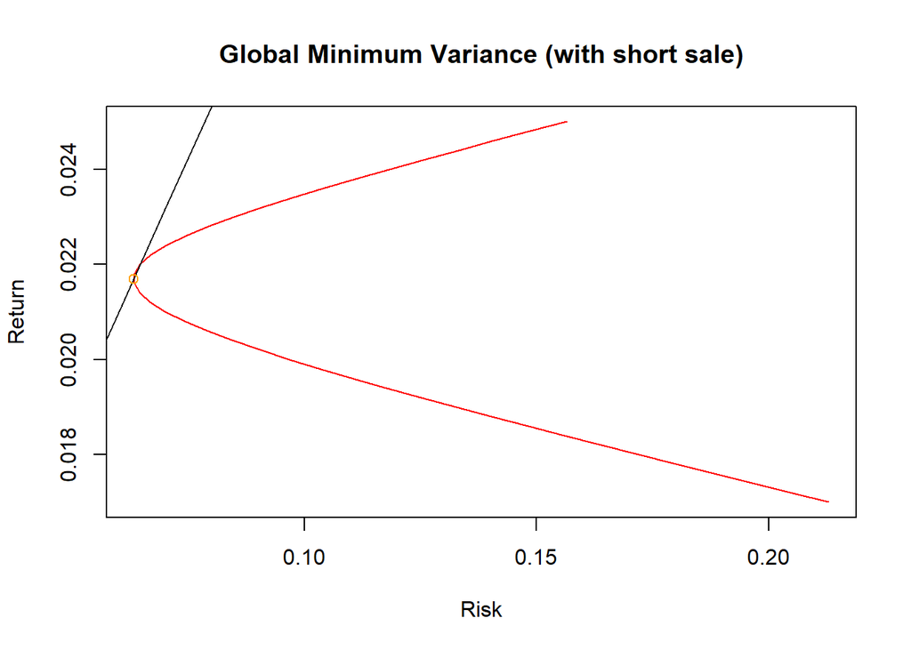

```r
# Plot of the efficient frontier, assume short sale allowed
w1WithShort <- seq(-2, 2, .1)
riskWithShort <- sqrt(fVar(w1WithShort))
returnWithShort <- r(w1WithShort)
plot(riskWithShort, returnWithShort, type='l', main='Global Minimum Variance (with short sale)', xlab = 'Risk', ylab = 'Return', col = 'red')
wp <- (var_rStock2 - cov_rStock1_rStock2) / (var_rStock1 + var_rStock2 - 2 * cov_rStock1_rStock2)  # Normalizing weight
Rp <- r(wp)
sigma <- sqrt(fVar(wp))
Rf <- mean_rf
Sharpe <- (Rp-Rf)/sigma
X <- seq(0, 1, .01)
Y <- Rf + Sharpe*X
lines(X, Y)
points(sigma, Rp, col='orange')
```

## c. **Graph the efficient frontier of portfolio with and without short sale together.**

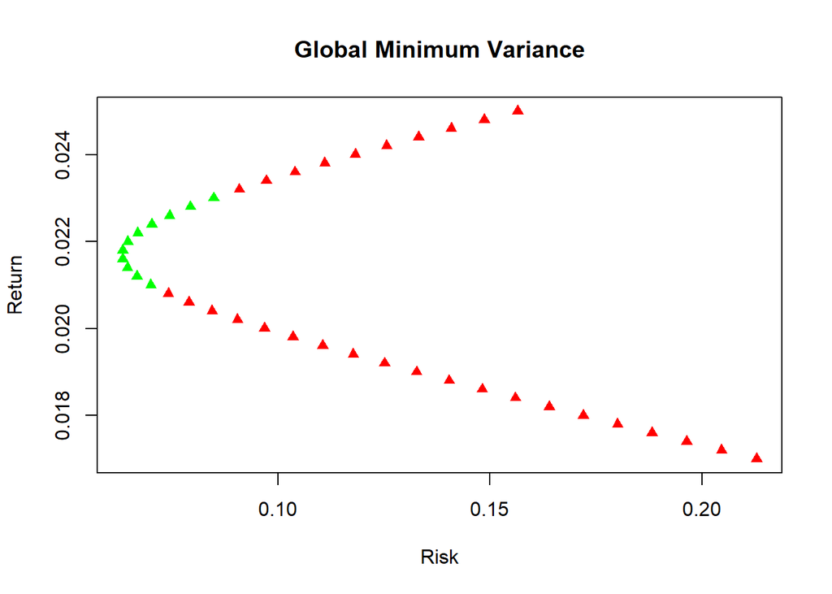

```r
# Changed input to display less points
w1WithoutShort <- seq(0, 1, .1)
riskWithoutShort <- sqrt(fVar(w1WithoutShort))
returnWithoutShort <- r(w1WithoutShort)
w1WithShort <- seq(-2, 2, .1)
riskWithShort <- sqrt(fVar(w1WithShort))
returnWithShort <- r(w1WithShort)


plot(riskWithShort, returnWithShort, main='Global Minimum Variance', xlab = 'Risk', ylab = 'Return', col = 'red', pch = 17)
points(riskWithoutShort, returnWithoutShort, col = 'green', pch = 17)
```

## d. **Graph the CAL and find the point of tangency.**

```r
w1 <- .3467
Rp <- r(w1)
sigma <- sqrt(fVar(w1))
CAL_slope <-(Rp - mean_rf) / sigma
CAL <- function(x) {mean_rf + CAL_slope * x}
```

The portfolio returns is:

$$\begin{equation}
\begin{aligned}
R_p & = w_1 * R_1 + w_2 * R_2 \\
& = 0.0216934 \\
\end{aligned}
\end{equation}$$

The portfolio returns variance is:

$$\begin{equation}
\begin{aligned}
\sigma_p & = w_1 * \sigma_1 + w_2 * \sigma_2 + 2 * w_1 * w_2 * \sigma_{1,2} \\
& = 0.063235 \\
\end{aligned}
\end{equation}$$

The slope of the Capital Allocation Line is:

$$\begin{equation}
\begin{aligned}
Slope_{CAL} & = \frac{R_p - r_f}{\sqrt{\sigma_p}} \\
& = 0.2165478 \\
\end{aligned}
\end{equation}$$

**Thus the Capital Allocation Line equation is $CAL = r_f + Slope_{CAL} * x = 0.008 + 0.2165478 * x$.**

**The tangency point is where the optimum weight is, i.e. $(\sigma_p, Rp)$ or $(0.063235, 0.0216934)$**

Graphing

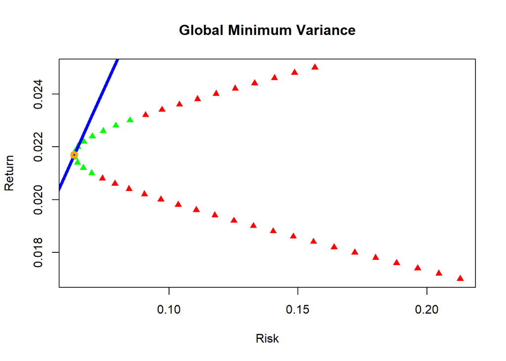

```r
# Plot of the efficient frontier, assume no short sale allowed
plot(riskWithShort, returnWithShort, main='Global Minimum Variance', xlab = 'Risk', ylab = 'Return', col = 'red', pch = 17)
points(riskWithoutShort, returnWithoutShort, col = 'green', pch = 17)
plot.function(CAL, add= TRUE, col = 'blue', lwd = 4)
points(sigma, Rp, col='orange', lwd = 4)
```

# **Question 4**

## a. Find the GMV solution.

```r
library(matlib)

vcov <- matrix(c(.04, .02, .001, .02, .03, .01, .001, .01, .025), 3, 3, byrow=TRUE)
vcovInverse <- inv(vcov)
vcovInverse
```

```
##           [,1]      [,2]      [,3]
## [1,]  39.70678 -29.93280  10.38485
## [2,] -29.93280  61.02627 -23.21319
## [3,]  10.38485 -23.21319  48.86988
```

Formulating the Markowitz portfolio problem:

$$\begin{equation}
\begin{aligned}
\text {The investor's objective is:} \\
max \mu_p & = w' * \mu \quad \text{s.t.} \\
\sigma_p^2 & = w' * (\sum) * w \quad \text{and} \quad w'*I = 1 \\
\text {where:} \\
w & = \quad \text{matrix of asset weights in the portfolio} \\
& =
\begin{pmatrix}
w_1 \\
w_2 \\
\end{pmatrix} \\
w' & = \quad \text{transpose matrix of asset weights in the portfolio} \\
& =
\begin{pmatrix}
w_1 & w_2 \\
\end{pmatrix} \\
\mu & = \quad \text{matrix of mean returns of asset in the portfolio} \\
& =
\begin{pmatrix}
\mu_1 \\
\mu_2 \\
\end{pmatrix} \\
\sum & = \quad \text{Variance-covariance matrix of asset returns in the the portfolio} \\
& =
\begin{pmatrix}
\sigma_1^2 & \sigma_{1,2} \\
\sigma_{1,2} & \sigma_2^2 \\
\end{pmatrix} \\
w'*I & = \sum_{i=1}^{n} w_n \quad \text{or the sum weights of the asset in the portfolio, I is notation for identity matrix} \\
\end{aligned}
\end{equation}$$

Let $\mu_{p,0}$ denotes a target expected return level. Formulate the problem:

$$\begin{equation}
\begin{aligned}
min \sigma_{p,w}^2 & = w' * (\sum) * w \quad \text{s.t.} \\
\mu_p & = w' * \mu = \mu_{p,0}, \quad \text{and} \quad w'*I = 1 \\
\end{aligned}
\end{equation}$$

To solve this, form the Lagrangian function:

$$\begin{equation}
\begin{aligned}
L(w, \lambda_1, \lambda_2) & = w'*\sum*w + \lambda_1*(w'*\mu - \mu_{p,0}) + \lambda_2*({w'*I - 1}) \\
\end{aligned}
\end{equation}$$

Because there are two constraints ($w'*\mu = \mu_{p,0}$ and $w'1 = 1$) there are two Langrange multipliers $\lambda_1$ and $\lambda_2$. The first order condition for a minimum are the linear equations:

$$\begin{equation}
\begin{aligned}
\frac{\partial L(w, \lambda_1, \lambda_2)}{\partial w} & = \frac{\partial (\sum * w^2)}{\partial w} + \frac{\partial (\lambda_1*(w'*\mu - \mu_{p,0}))}{\partial w} + \frac{\lambda_2*({w'*I - 1})}{\partial w} = 0 \\
\frac{\partial L(w, \lambda_1, \lambda_2)}{\partial \lambda_1} & = 0 \\
\frac{\partial L(w, \lambda_1, \lambda_2)}{\partial \lambda_2} & = 0 \\
\end{aligned}
\end{equation}$$

Simplify, we have:

$$\begin{equation}
\begin{aligned}
\frac{\partial L(w, \lambda_1, \lambda_2)}{\partial w} & = 2*\sum*w + \lambda_1*\mu + \lambda_2*I = 0 \\
\frac{\partial L(w, \lambda_1, \lambda_2)}{\partial \lambda_1} & = w'*\mu - \mu_{p,0} = 0 \\
\frac{\partial L(w, \lambda_1, \lambda_2)}{\partial \lambda_2} & = w'*I - 1 = 0 \\
\end{aligned}
\end{equation}$$

Rewrite in matrix form:

$$\begin{equation}
\begin{aligned}
\begin{pmatrix}
2*\sum & \mu & I \\
\mu' & 0 & 0 \\
I' & 0 & 0 \\
\end{pmatrix}
*
\begin{pmatrix}
w \\
\lambda_1 \\
\lambda_2 \\
\end{pmatrix}
& =
\begin{pmatrix}
0 \\
\mu_{p,0} \\
I \\
\end{pmatrix}
\end{aligned}
\end{equation}$$

or

$$\begin{equation}
\begin{aligned}
A * z_w & = b_0 \\
\text{where}\\
A & =
\begin{pmatrix}
2*\sum & \mu & I \\
\mu' & 0 & 0 \\
I' & 0 & 0 \\
\end{pmatrix} \\
z_w & =
\begin{pmatrix}
w \\
\lambda_1 \\
\lambda_2 \\
\end{pmatrix} \\
b_0 & =
\begin{pmatrix}
0 \\
\mu_{p,0} \\
I \\
\end{pmatrix}
\end{aligned}
\end{equation}$$

The solution for $z_w$ is:

$$\begin{equation}
\begin{aligned}
z_w & = A^{-1} * b_0
\end{aligned}
\end{equation}$$

```r
topMatrix <- cbind(2*vcovInverse, rep(1, 3))
bottomVector <- c(rep(1, 3), 0)
AmMatrix <- rbind(topMatrix, bottomVector)
bVector <- c(rep(0, 3), 1)
zmMatrix <- solve(AmMatrix)%*%bVector
mVector <- zmMatrix[1:3,1]
mVector
```

```
## [1] 0.3885350 0.3821656 0.2292994
```

Thus, the optimum weights of each stocks in the portfolio to satisfy the objective of minimum risk is:

| Asset | Weight |
| --- | --- |
| Stock A | 38.8535% |
| Stock B | 38.21656% |
| Stock C | 22.92994% |

## b. Find the GMV solution with constraint.

```r
vcovInverse
```

```
##           [,1]      [,2]      [,3]
## [1,]  39.70678 -29.93280  10.38485
## [2,] -29.93280  61.02627 -23.21319
## [3,]  10.38485 -23.21319  48.86988
```

```r
mean_rStockA <- .0375
mean_rStockB <- .0420
mean_rStockC <- .0300
mean_rf <- .0225
returnsVector <- rbind(mean_rStockA, mean_rStockB, mean_rStockC)  # Establish returns vector
riskPremiumMatrix <- returnsVector - mean_rf
```

We have the z vector:

$$\begin{equation}
\begin{aligned}
z & = (\sum)^{-1} * (R - Rf) \\
& =
\begin{pmatrix}
39.70678 & -29.93280 & 10.38485 \\
-29.93280 & 61.02627 & -23.21319 \\
10.38485 & -23.21319 & 48.86988 \\
\end{pmatrix}
*
\begin{pmatrix}
0.0150 \\
0.0195 \\
0.0075 \\
\end{pmatrix}
& =
\begin{pmatrix}
0.08979841 \\
0.56692120 \\
0.06963958 \\
\end{pmatrix}
\end{aligned}
\end{equation}$$

```r
z <- vcovInverse %*% riskPremiumMatrix
```

The lambda value is thus:

$$\begin{equation}
\begin{aligned}
\lambda & = 0.7263592\\
\end{aligned}
\end{equation}$$

```r
lambda <- sum(z)
w1 <- z[1] / lambda
w2 <- z[2] / lambda
w3 <- z[3] / lambda
```

Therefore, the weight of these stocks are:

$$\begin{equation}
\begin{aligned}
w_1 & = \frac{z_i}{\sum_{i=1}^{n} z_i} \\
& = \frac{0.0897984}{0.7263592} \\
& = 0.1236281 \\
\text{and} \\
w_2 & = \frac{z_i}{\sum_{i=1}^{n} z_i} \\
& = \frac{0.5669212}{0.7263592} \\
& = 0.780497 \\
\text{and} \\
w_3 & = \frac{z_i}{\sum_{i=1}^{n} z_i} \\
& = \frac{0.0696396}{0.7263592} \\
& = 0.0958749 \\
\end{aligned}
\end{equation}$$

**Recap:**

| Asset | Weight |
| --- | --- |
| Stock A | 12.3628107% |
| Stock B | 78.0497035% |
| Stock C | 9.5874858% |